# Self-restraint as mediator - EFA Victimization

2026-09-14

# 0. Setup

#1. Cleaning

```r
df_r <- read.csv("lgbtPKU.csv")
```

Raw data dim: 853, 224

## renaming for categoricals and ordinals

```r
df <- df_r |>
  rename(
         grade = Q7,
         sexual_orientation = Q12,
         nonconformity_masculine = Q14,
         nonconformity_feminine = Q15,
         support_from_queer = Q25_行1,
         support_from_nonqueer = Q25_行1
         ) |>
  mutate(
# Sex
    assigned_male = ifelse(Q10 != 3, 2 - Q10, NA),
    assigned_female = 1 - assigned_male,
    documented_male = 2 - Q9,
    documented_female = 1 - documented_male,

# Age
    age = 33 - Q3,

# LGBTQ+
    cisgender = 2 - Q11,
    transgender = 1 - cisgender,
    LGBTQ = ifelse(Q10 != 3 & cisgender == 1 & sexual_orientation == 2, 0, 1),

# outness
    outness = 2 - Q16,
    out_to_teacher = ifelse(Q17 == 1, 1, 0),
    public_out = ifelse(Q21 == 1, 1, 0),
    out_to_queer_friends = ifelse(Q23 == -3, 1, Q23),
    out_to_nonqueer_friends = ifelse(Q24 == -3, 1, Q24),

# Victimization and perceived LGBTQ+ affirming attitude
    perceived_acceptance_teacher = 5 - Q19,
    perceived_acceptance_student = 5 - Q28,

    victimization_teacher = 1 - Q20_选项17,
    victimization_student = 1 - Q29_选项14,
    victimization_ever = ifelse(victimization_teacher == 1 | victimization_student == 1, 1, 0),

#Self-restraint of gender expression
    self_restraint_teacher = 5 - Q18,
    self_restraint_allstudent = 10 - Q27_行1 - Q27_行2,
    self_restraint_otherLGBTQ = 5 - Q27_行1,
    self_restraint_otherstudents = 5 - Q27_行2,
    self_restraint = self_restraint_teacher + self_restraint_allstudent - 3,

# self-esteem: Rosenberg Self-Esteem Scale, RSES
    Q31_行3_r  = 6 - Q31_行3,
    Q31_行5_r  = 6 - Q31_行5,
    Q31_行8_r  = 6 - Q31_行8,
    Q31_行9_r  = 6 - Q31_行9,
    Q31_行10_r = 6 - Q31_行10,

    self_esteem = rowSums(
      pick(all_of(c(
        "Q31_行1", "Q31_行2", "Q31_行3_r", "Q31_行4", "Q31_行5_r", "Q31_行6", "Q31_行7", "Q31_行8_r", "Q31_行9_r", "Q31_行10_r"
      ))),
      na.rm = TRUE
    ),


# depression: Center for Epidemiologic Studies Depression Scale, CESD 9-item Chinese version
    Q30_行5_r = 5 - Q30_行5,
    Q30_行7_r = 5 - Q30_行7,
    depression = Q30_行1 + Q30_行2 + Q30_行3 + Q30_行4 + Q30_行5_r + Q30_行6 + Q30_行7_r + Q30_行8 + Q30_行9,

#anxiety: Generalized Anxiety Disorder Scale, GAD-7
    anxiety = rowSums(
      pick(all_of(c("Q32_行1", "Q32_行2", "Q32_行3", "Q32_行4", "Q32_行5", "Q32_行6", "Q32_行7"))), na.rm = TRUE
    )
  )
```

Renamed data dim: 853, 257

## drop inconsistent cases

```r
#drop one inconsistent case
df1 <- df |>
  filter(!((documented_female == 1 & assigned_male == 1 & transgender == 0) | (documented_male == 1 & assigned_female == 1 & transgender == 0)) %in% TRUE) |>

#drop two cases that non-LGBTQ+ reported coming out
  filter(!(LGBTQ == 0 & outness == 1)) |>

#constantly filling the same value for multiple question matrices
  filter(!(index == 1273)) |>

#drop age under 18 (5 cases)
  filter(!(age < 18))
```

Dim after some obs dropped: 844, 257

#2.3. victm EFA

```r
vic_q <- df1 |>
  select(
    # Q20
    Q20_选项1, Q20_选项2, Q20_选项3, Q20_选项4, Q20_选项5,
    Q20_选项6, Q20_选项7, Q20_选项8, Q20_选项9, Q20_选项10,
    Q20_选项11, Q20_选项12, Q20_选项13, Q20_选项14, Q20_选项15,

    # Q29
    Q29_选项1, Q29_选项2, Q29_选项3, Q29_选项4, Q29_选项5,
    Q29_选项6, Q29_选项7, Q29_选项8, Q29_选项9, Q29_选项10,
    Q29_选项11, Q29_选项12
  )

# Give items shorter names for easier interpretation
names(vic_q) <- c(
  paste0("Q20_", 1:15),
  paste0("Q29_", 1:12)
)
```

Questions on Victimization: Q20_1, Q20_2, Q20_3, Q20_4, Q20_5, Q20_6, Q20_7, Q20_8, Q20_9, Q20_10, Q20_11, Q20_12, Q20_13, Q20_14, Q20_15, Q29_1, Q29_2, Q29_3, Q29_4, Q29_5, Q29_6, Q29_7, Q29_8, Q29_9, Q29_10, Q29_11, Q29_12

## 1. Check

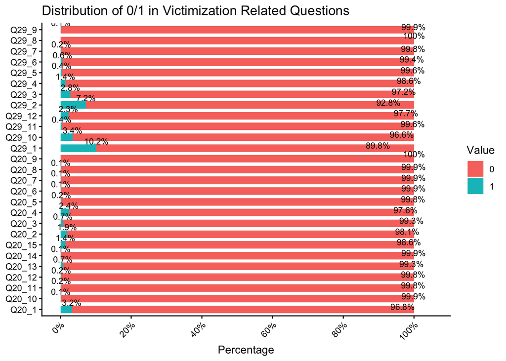

```r
# Find variables that contain only 0, 1, and possibly NA
binary_vars <- vic_q |>
  select(where(~ all(na.omit(.) %in% c(0, 1)))) |>
  names()

# Calculate percentage of 0 and 1 for each variable
plot_data <- vic_q |>
  select(all_of(binary_vars)) |>
  pivot_longer(
    cols = everything(),
    names_to = "variable",
    values_to = "value"
  ) |>
  filter(!is.na(value)) |>
  count(variable, value) |>
  group_by(variable) |>
  mutate(
    percentage = n / sum(n) * 100
  ) |>
  ungroup()

# Plot
plot_data |>

  ggplot(
    aes(x = variable, y = percentage, fill = factor(value))
  ) +
  geom_col(
    width = 0.7
  ) +
  geom_text(
    aes(label = paste0(round(percentage, 1), "%")),
    position = position_dodge(width = 0.8),
    vjust = -0.3,
    size = 3
  ) +
  scale_y_continuous(
    limits = c(0, 105),
    breaks = seq(0, 100, 20),
    labels = function(x) paste0(x, "%")
  ) +
  labs(
    x = NULL,
    y = "Percentage",
    fill = "Value",
    title = "Distribution of 0/1 in Victimization Related Questions"
  ) +
  theme_classic() +
    theme(
      axis.text.x = element_text(
        angle = 45,
        hjust = 1
      )
    ) +
  coord_flip()
```

Slightly too many 0s. “The problem is that for binary variables, extremely rare 1s provide very little information about how items relate to each other. This becomes especially important in your analysis because you’re using tetrachoric correlations.” - chatgpt

## 2. Delete those with 0 variance and with 99% 0

```r
vars_to_remove = names(vic_q)[sapply(vic_q, function(x) {
  x <- x[!is.na(x)]
  length(x) == 0 ||
    length(unique(x)) == 1 ||     # zero variance
    mean(x == 0) >= 0.99         # 99.5% or more are 0
})]

vic_clean = vic_q |>
  select(-all_of(vars_to_remove))
```

Deleted variables: Q20_3, Q20_5, Q20_6, Q20_7, Q20_8, Q20_9, Q20_10, Q20_11, Q20_12, Q20_13, Q20_14, Q29_5, Q29_6, Q29_7, Q29_8, Q29_9, Q29_11

## 3. Tetrachoric correlation matrix

For binary items, this is preferable to ordinary Pearson correlations:

```r
corr <- tetrachoric(vic_clean)
eigen(corr$rho)$values
```

```
##  [1] 5.050146e+00 1.368775e+00 1.151644e+00 7.660467e-01 6.580878e-01
##  [6] 5.436084e-01 2.383016e-01 2.233904e-01 9.878751e-11 9.843636e-11
```

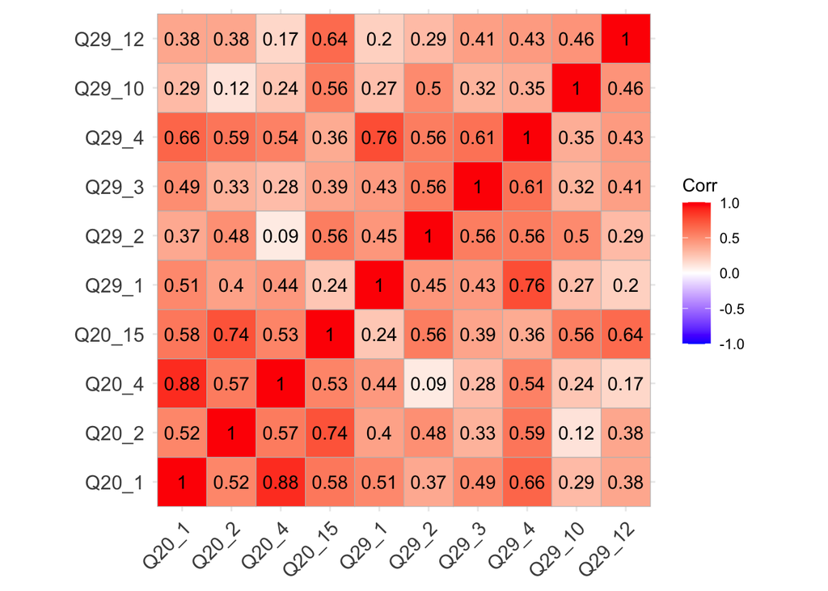

```r
ggcorrplot(corr$rho, lab = TRUE)
```

## 4. Scree Plot

```r
eigen = fa.parallel(vic_clean, cor='poly', fa = "pc")
```

```
## In smc, smcs < 0 were set to .0
## In smc, smcs < 0 were set to .0
## In smc, smcs < 0 were set to .0
```

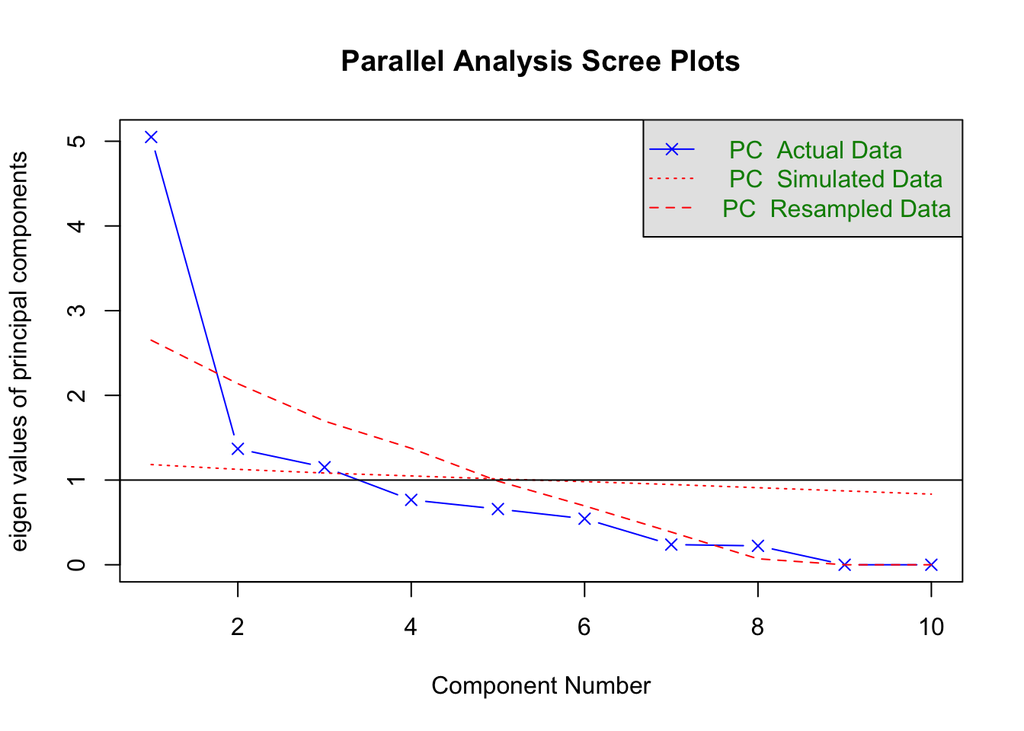

```
## Parallel analysis suggests that the number of factors =  NA  and the number of components =  3
```

Eigenvalues

```r
round(eigen$pc.values, digit = 2)
```

```
##  [1] 5.05 1.37 1.15 0.77 0.66 0.54 0.24 0.22 0.00 0.00
```

## 5. EFA

### 3-factor

```r
efa_3 <- fa(
  corr$rho,
  nfactors = 3,
  n.obs = nrow(vic_clean),
  fm = "minres",
  rotate = "oblimin"
)
```

```
## In smc, smcs < 0 were set to .0
## In smc, smcs < 0 were set to .0
## In smc, smcs < 0 were set to .0
```

```r
efa_3
```

```
## Factor Analysis using method =  minres
## Call: fa(r = corr$rho, nfactors = 3, n.obs = nrow(vic_clean), rotate = "oblimin",
##     fm = "minres")
## Standardized loadings (pattern matrix) based upon correlation matrix
##          MR1   MR3   MR2   h2     u2 com
## Q20_1   0.33  0.19  0.61 0.79  0.213 1.8
## Q20_2   0.23  0.40  0.30 0.51  0.492 2.5
## Q20_4   0.05  0.09  0.96 1.03 -0.026 1.0
## Q20_15 -0.08  1.01  0.15 1.06 -0.062 1.1
## Q29_1   0.75 -0.14  0.16 0.59  0.410 1.2
## Q29_2   0.62  0.41 -0.31 0.64  0.360 2.3
## Q29_3   0.59  0.20 -0.07 0.46  0.535 1.3
## Q29_4   0.93 -0.06  0.16 0.95  0.055 1.1
## Q29_10  0.24  0.50 -0.15 0.36  0.641 1.7
## Q29_12  0.18  0.57 -0.08 0.42  0.582 1.2
##
##                        MR1  MR3  MR2
## SS loadings           2.74 2.31 1.75
## Proportion Var        0.27 0.23 0.18
## Cumulative Var        0.27 0.50 0.68
## Proportion Explained  0.40 0.34 0.26
## Cumulative Proportion 0.40 0.74 1.00
##
##  With factor correlations of
##      MR1  MR3  MR2
## MR1 1.00 0.44 0.36
## MR3 0.44 1.00 0.31
## MR2 0.36 0.31 1.00
##
## Mean item complexity =  1.5
## Test of the hypothesis that 3 factors are sufficient.
##
## df null model =  45  with the objective function =  48.23 with Chi Square =  40459.15
## df of  the model are 18  and the objective function was  40.98
##
## The root mean square of the residuals (RMSR) is  0.04
## The df corrected root mean square of the residuals is  0.06
##
## The harmonic n.obs is  844 with the empirical chi square  127.86  with prob <  1.4e-18
## The total n.obs was  844  with Likelihood Chi Square =  34289.47  with prob <  0
##
## Tucker Lewis Index of factoring reliability =  -1.125
## RMSEA index =  1.502  and the 90 % confidence intervals are  1.49 1.516
## BIC =  34168.18
## Fit based upon off diagonal values = 0.99
## Measures of factor score adequacy
##                                                    MR1  MR3  MR2
## Correlation of (regression) scores with factors   0.93 0.99 0.95
## Multiple R square of scores with factors          0.86 0.98 0.89
## Minimum correlation of possible factor scores     0.73 0.96 0.79
```

```r
efa_3$loadings
```

```
##
## Loadings:
##        MR1    MR3    MR2
## Q20_1   0.331  0.190  0.608
## Q20_2   0.228  0.399  0.303
## Q20_4                 0.960
## Q20_15         1.010  0.153
## Q29_1   0.752 -0.139  0.156
## Q29_2   0.615  0.405 -0.309
## Q29_3   0.593  0.202
## Q29_4   0.926         0.161
## Q29_10  0.239  0.499 -0.153
## Q29_12  0.179  0.574
##
##                  MR1   MR3   MR2
## SS loadings    2.415 2.028 1.588
## Proportion Var 0.242 0.203 0.159
## Cumulative Var 0.242 0.444 0.603
```

EFA3: communality and uniqueness

```r
efa_3$communality
```

```
##     Q20_1     Q20_2     Q20_4    Q20_15     Q29_1     Q29_2     Q29_3     Q29_4
## 0.7874300 0.5076820 1.0260231 1.0619590 0.5900241 0.6402418 0.4647554 0.9452357
##    Q29_10    Q29_12
## 0.3594914 0.4175158
```

```r
efa_3$uniquenesses
```

```
##       Q20_1       Q20_2       Q20_4      Q20_15       Q29_1       Q29_2
##  0.21256999  0.49231804 -0.02602313 -0.06195904  0.40997593  0.35975822
##       Q29_3       Q29_4      Q29_10      Q29_12
##  0.53524459  0.05476425  0.64050862  0.58248422
```

Communality is the proportion of an item’s variance explained by the common factors in your EFA. Uniqueness is the portion not explained by the common factors:

*Q20——选项4 Q20_选项15 require further investigation.*

Q20_4 $h^2$ = 1.026 $\leftarrow$ improper Q20_15 $h^2$ = 1.062 $\leftarrow$ improper Q29_4 $h^2$ = 0.945 $\leftarrow$ technically proper, but unusually high

```r
colMeans(vic_clean[, c("Q20_4", "Q20_15", "Q29_4")], na.rm = TRUE)
```

```
##      Q20_4     Q20_15      Q29_4
## 0.02369668 0.01421801 0.01421801
```

```r
round(corr$rho[c("Q20_4", "Q20_15", "Q29_4"), ], 3)
```

```
##        Q20_1 Q20_2 Q20_4 Q20_15 Q29_1 Q29_2 Q29_3 Q29_4 Q29_10 Q29_12
## Q20_4  0.878 0.573 1.000  0.530 0.437 0.090 0.281 0.536  0.237  0.169
## Q20_15 0.583 0.743 0.530  1.000 0.238 0.556 0.391 0.357  0.564  0.638
## Q29_4  0.661 0.587 0.536  0.357 0.757 0.561 0.608 1.000  0.353  0.431
```

### neighbors

```r
efa_2 <- fa(
  corr$rho,
  nfactors = 2,
  n.obs = nrow(vic_clean),
  fm = "minres",
  rotate = "oblimin"
)
```

```
## In smc, smcs < 0 were set to .0
## In smc, smcs < 0 were set to .0
## In smc, smcs < 0 were set to .0
```

```r
efa_2
```

```
## Factor Analysis using method =  minres
## Call: fa(r = corr$rho, nfactors = 2, n.obs = nrow(vic_clean), rotate = "oblimin",
##     fm = "minres")
## Standardized loadings (pattern matrix) based upon correlation matrix
##          MR1   MR2   h2     u2 com
## Q20_1   0.27  0.75 0.81  0.189 1.3
## Q20_2   0.43  0.40 0.49  0.506 2.0
## Q20_4  -0.09  1.04 1.01 -0.014 1.0
## Q20_15  0.65  0.21 0.58  0.416 1.2
## Q29_1   0.40  0.32 0.37  0.625 1.9
## Q29_2   0.87 -0.17 0.66  0.344 1.1
## Q29_3   0.62  0.08 0.44  0.565 1.0
## Q29_4   0.58  0.37 0.65  0.346 1.7
## Q29_10  0.62 -0.08 0.34  0.656 1.0
## Q29_12  0.61 -0.01 0.36  0.636 1.0
##
##                        MR1  MR2
## SS loadings           3.34 2.40
## Proportion Var        0.33 0.24
## Cumulative Var        0.33 0.57
## Proportion Explained  0.58 0.42
## Cumulative Proportion 0.58 1.00
##
##  With factor correlations of
##      MR1  MR2
## MR1 1.00 0.43
## MR2 0.43 1.00
##
## Mean item complexity =  1.3
## Test of the hypothesis that 2 factors are sufficient.
##
## df null model =  45  with the objective function =  48.23 with Chi Square =  40459.15
## df of  the model are 26  and the objective function was  42.68
##
## The root mean square of the residuals (RMSR) is  0.07
## The df corrected root mean square of the residuals is  0.1
##
## The harmonic n.obs is  844 with the empirical chi square  405.76  with prob <  8.4e-70
## The total n.obs was  844  with Likelihood Chi Square =  35740.85  with prob <  0
##
## Tucker Lewis Index of factoring reliability =  -0.532
## RMSEA index =  1.276  and the 90 % confidence intervals are  1.265 1.288
## BIC =  35565.66
## Fit based upon off diagonal values = 0.98
## Measures of factor score adequacy
##                                                    MR1  MR2
## Correlation of (regression) scores with factors   0.92 0.99
## Multiple R square of scores with factors          0.85 0.98
## Minimum correlation of possible factor scores     0.70 0.96
```

```r
efa_2$loadings
```

```
##
## Loadings:
##        MR1    MR2
## Q20_1   0.273  0.748
## Q20_2   0.432  0.398
## Q20_4          1.043
## Q20_15  0.646  0.214
## Q29_1   0.403  0.318
## Q29_2   0.870 -0.173
## Q29_3   0.620
## Q29_4   0.578  0.367
## Q29_10  0.617
## Q29_12  0.606
##
##                  MR1   MR2
## SS loadings    3.072 2.131
## Proportion Var 0.307 0.213
## Cumulative Var 0.307 0.520
```

EFA2: communality and uniqueness

```r
efa_2$communality
```

```
##     Q20_1     Q20_2     Q20_4    Q20_15     Q29_1     Q29_2     Q29_3     Q29_4
## 0.8114892 0.4939999 1.0144887 0.5836232 0.3746115 0.6559922 0.4352505 0.6539881
##    Q29_10    Q29_12
## 0.3444892 0.3635778
```

```r
efa_2$uniquenesses
```

```
##       Q20_1       Q20_2       Q20_4      Q20_15       Q29_1       Q29_2
##  0.18851079  0.50600009 -0.01448871  0.41637682  0.62538855  0.34400777
##       Q29_3       Q29_4      Q29_10      Q29_12
##  0.56474953  0.34601195  0.65551079  0.63642215
```

```r
efa_4 <- fa(
  corr$rho,
  nfactors = 4,
  n.obs = nrow(vic_clean),
  fm = "minres",
  rotate = "oblimin"
)
```

```
## In smc, smcs < 0 were set to .0
## In smc, smcs < 0 were set to .0
## In smc, smcs < 0 were set to .0
```

```r
efa_4
```

```
## Factor Analysis using method =  minres
## Call: fa(r = corr$rho, nfactors = 4, n.obs = nrow(vic_clean), rotate = "oblimin",
##     fm = "minres")
## Standardized loadings (pattern matrix) based upon correlation matrix
##          MR1   MR3   MR2   MR4   h2     u2 com
## Q20_1   0.28  0.17  0.71 -0.02 0.83  0.169 1.4
## Q20_2   0.14  0.05  0.06  0.91 1.01 -0.015 1.1
## Q20_4   0.00  0.01  0.99  0.05 1.02 -0.023 1.0
## Q20_15 -0.14  0.82  0.17  0.33 1.04 -0.037 1.5
## Q29_1   0.71 -0.11  0.16  0.04 0.59  0.412 1.2
## Q29_2   0.58  0.38 -0.29  0.17 0.64  0.360 2.5
## Q29_3   0.56  0.24  0.01 -0.01 0.47  0.531 1.4
## Q29_4   0.87 -0.05  0.16  0.11 0.94  0.061 1.1
## Q29_10  0.21  0.72  0.04 -0.30 0.57  0.433 1.5
## Q29_12  0.14  0.56  0.00  0.04 0.42  0.582 1.1
##
##                        MR1  MR3  MR2  MR4
## SS loadings           2.42 2.01 1.84 1.26
## Proportion Var        0.24 0.20 0.18 0.13
## Cumulative Var        0.24 0.44 0.63 0.75
## Proportion Explained  0.32 0.27 0.24 0.17
## Cumulative Proportion 0.32 0.59 0.83 1.00
##
##  With factor correlations of
##      MR1  MR3  MR2  MR4
## MR1 1.00 0.37 0.37 0.31
## MR3 0.37 1.00 0.26 0.38
## MR2 0.37 0.26 1.00 0.42
## MR4 0.31 0.38 0.42 1.00
##
## Mean item complexity =  1.4
## Test of the hypothesis that 4 factors are sufficient.
##
## df null model =  45  with the objective function =  48.23 with Chi Square =  40459.15
## df of  the model are 11  and the objective function was  39.83
##
## The root mean square of the residuals (RMSR) is  0.03
## The df corrected root mean square of the residuals is  0.06
##
## The harmonic n.obs is  844 with the empirical chi square  59.62  with prob <  1.1e-08
## The total n.obs was  844  with Likelihood Chi Square =  33301.75  with prob <  0
##
## Tucker Lewis Index of factoring reliability =  -2.381
## RMSEA index =  1.894  and the 90 % confidence intervals are  1.878 1.912
## BIC =  33227.63
## Fit based upon off diagonal values = 1
## Measures of factor score adequacy
##                                                    MR1  MR3  MR2  MR4
## Correlation of (regression) scores with factors   0.89 0.88 0.96 0.86
## Multiple R square of scores with factors          0.79 0.78 0.93 0.75
## Minimum correlation of possible factor scores     0.59 0.56 0.85 0.49
```

```r
efa_4$loadings
```

```
##
## Loadings:
##        MR1    MR3    MR2    MR4
## Q20_1   0.277  0.167  0.706
## Q20_2   0.137                0.907
## Q20_4                 0.987
## Q20_15 -0.143  0.823  0.175  0.331
## Q29_1   0.715 -0.112  0.161
## Q29_2   0.576  0.381 -0.294  0.172
## Q29_3   0.560  0.240
## Q29_4   0.872         0.159  0.115
## Q29_10  0.209  0.717        -0.303
## Q29_12  0.141  0.561
##
##                  MR1   MR3   MR2   MR4
## SS loadings    2.095 1.755 1.647 1.073
## Proportion Var 0.210 0.175 0.165 0.107
## Cumulative Var 0.210 0.385 0.550 0.657
```

EFA4: communality and uniqueness

```r
efa_4$communality
```

```
##     Q20_1     Q20_2     Q20_4    Q20_15     Q29_1     Q29_2     Q29_3     Q29_4
## 0.8313134 1.0148406 1.0230760 1.0366938 0.5879801 0.6395857 0.4688549 0.9390225
##    Q29_10    Q29_12
## 0.5674175 0.4175781
```

```r
efa_4$uniquenesses
```

```
##       Q20_1       Q20_2       Q20_4      Q20_15       Q29_1       Q29_2
##  0.16868658 -0.01484064 -0.02307604 -0.03669375  0.41201995  0.36041427
##       Q29_3       Q29_4      Q29_10      Q29_12
##  0.53114513  0.06097749  0.43258248  0.58242189
```